# Python Chunks in the Bio7 Markdown Editor

# Python chunks

A chunk which starts with `` ```{python} `` runs in the **embedded Python** of Bio7 (the same Python as the console, the Python-Shell and the scripts). Run a chunk with the ▶ button in the bar above the chunk, all chunks above with ▶▶ (Run Above), or all chunks of the document with *Run All*. The output is shown below the chunk. Python is started automatically if it is not running.

The variables are created in the workspace of Python (`__main__`): they are available in the following chunks, the console and the Python-Shell view.

```python
import numpy as np
import pandas as pd

rng = np.random.default_rng(42)
x = np.linspace(0, 10, 50)
y = 2.5 * x + rng.normal(0, 2, x.size)
print("Created", x.size, "values")
```

```
## Created 50 values
```

## The value of the last expression is printed

```python
data = pd.DataFrame({"x": x, "y": y})
data.describe().round(2)
```

```
##            x      y
## count  50.00  50.00
## mean    5.00  12.68
## std     2.97   7.85
## min     0.00  -1.86
## 25%     2.50   6.78
## 50%     5.00  12.86
## 75%     7.50  19.34
## max    10.00  25.85
```

## A linear model with numpy

```python
slope, intercept = np.polyfit(x, y, 1)
residuals = y - (slope * x + intercept)
r2 = 1 - residuals.var() / y.var()
f"y = {slope:.2f} * x + {intercept:.2f}   (R² = {r2:.3f})"
```

```
## 'y = 2.59 * x + -0.27   (R² = 0.963)'
```

## Plots

A matplotlib figure of a chunk is shown below the chunk (in the size of the plots of the editor, unless a `figsize` is given).

[figure not shown]

```python
import matplotlib.pyplot as plt

plt.scatter(x, y, s=18, alpha=0.7, label="data")
plt.plot(x, slope * x + intercept, color="crimson", label="fit")
plt.xlabel("x")
plt.ylabel("y")
plt.legend()
plt.title("Linear regression")
plt.show()
```

Several figures (or subplots) of one chunk are shown one below the other:

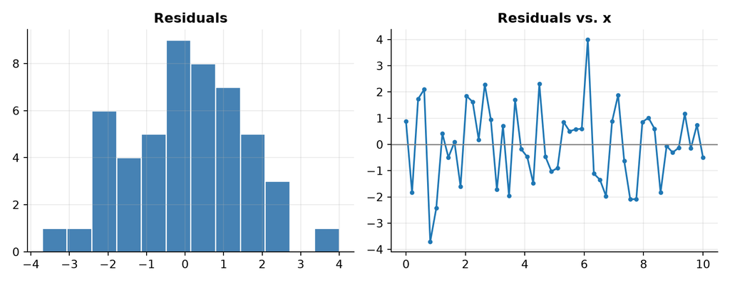

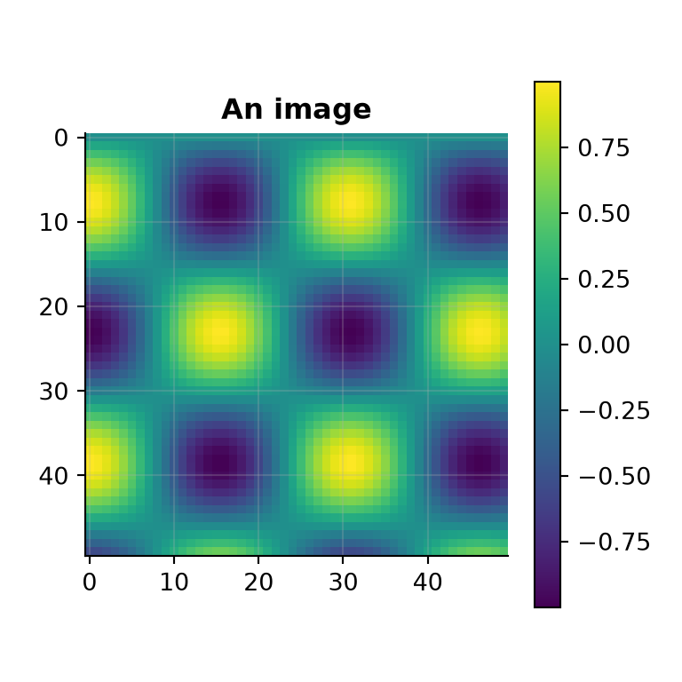

```python
fig, axes = plt.subplots(1, 2, figsize=(9, 3.5))
axes[0].hist(residuals, bins=12, color="steelblue", edgecolor="white")
axes[0].set_title("Residuals")
axes[1].plot(x, residuals, "o-", markersize=3)
axes[1].axhline(0, color="gray", lw=1)
axes[1].set_title("Residuals vs. x")
fig.tight_layout()

fig2 = plt.figure(figsize=(4, 4))
plt.imshow(np.outer(np.sin(x), np.cos(x)), cmap="viridis")
plt.colorbar()
plt.title("An image")
```

## Errors

The error is shown below the chunk and stops *Run All*. When the document is rendered (knitr), an error stops the rendering unless the chunk has the option `error=TRUE` (as this one). If a variable is used which is created in a chunk above that was not run yet (e.g., `x` after a restart of Bio7), the hint to run the chunks above (▶▶) is shown.

```python
print(undefined_variable)
```

```
## Traceback (most recent call last):
##   File "<chunk>", line 1, in <module>
## NameError: name 'undefined_variable' is not defined
```